# Dispersal mortality

In this notebook, we demonstrate the possibility to use independent movement probablities and costs, similar to (Fletcher Jr et al. 2019) and (Marx et al. 2020).

## Preamble

See notebook Getting Started for a ‘basic workflow’ to learn about the fundamentals on data import and the creation of a ConScape `Grid`:

```
"/home/runner/work/ConScape.jl/ConScape.jl/src/../data"
```

We use the data provided in (Marx et al. 2020):

```
┌ 174×99 Raster{Float64, 2} ┐
├───────────────────────────┴──────────────────────────────────────────── dims ┐
  ↓ X Projected{Float64} 615138.0:500.0:701638.0 ForwardOrdered Regular Intervals{Start},
  → Y Projected{Float64} 306108.0:-500.0:257108.0 ReverseOrdered Regular Intervals{Start}
├──────────────────────────────────────────────────────────────────── metadata ┤
  Metadata{Rasters.GDALsource} of Dict{String, Any} with 1 entry:
  "filepath" => "/home/runner/work/ConScape.jl/ConScape.jl/src/../data/prob_pan…
├────────────────────────────────────────────────────────────────────── raster ┤
  missingval: NaN
  extent: Extent(X = (615138.0, 702138.0), Y = (257108.0, 306608.0))
  crs:
└──────────────────────────────────────────────────────────────────────────────┘
      ↓ →  306108.0       305608.0       …  257608.0       257108.0
 615138.0       0.111111       0.125           NaN            NaN
 615638.0       0.5            0.125           NaN            NaN
      ⋮                                  ⋱
 701138.0       0.111111       0.111111          1.0            1.0
 701638.0       0.166667       0.166667          0.111111       0.333333
```

Note, we did not have quality data for each pixel, for this demonstration we simply assumed that the movementl likelihood adequately represents quality (see Notebook Getting Started for a better example with independent quality data).

We remove negative values:

## Cost data

In addition to the data on the habitat quality and the likelihood of movement, we also have independent data on the cost of movement ((Marx et al. 2020)):

We can then create a `RasterStack` from the three input `Raster`s:

```
┌ 174×99 RasterStack ┐
├────────────────────┴─────────────────────────────────────────────────── dims ┐
  ↓ X Projected{Float64} 615138.0:500.0:701638.0 ForwardOrdered Regular Intervals{Start},
  → Y Projected{Float64} 306108.0:-500.0:257108.0 ReverseOrdered Regular Intervals{Start}
├────────────────────────────────────────────────────────────────────── layers ┤
  :quality        eltype: Float64 dims: X, Y size: 174×99
  :steplikelihood eltype: Float64 dims: X, Y size: 174×99
  :cost           eltype: Float64 dims: X, Y size: 174×99
├────────────────────────────────────────────────────────────────────── raster ┤
  missingval: NaN
  extent: Extent(X = (615138.0, 702138.0), Y = (257108.0, 306608.0))
  crs:
└──────────────────────────────────────────────────────────────────────────────┘
```

## Computing the survival probability

Use the Randomised Shortest Path movement mode:

Note that to compute the survival probability from $s$ to $t$ corresponding to the mortality cost associated to edges $(i,j)$, we need to set $\theta=1.0$ ((Moorter et al. 2021)).

```
1
```

```
GLMakie.Screen(...)
```

Finally, we can use these survival probabilities to compute for each pixel the amount of habitat it is functionally connected to:

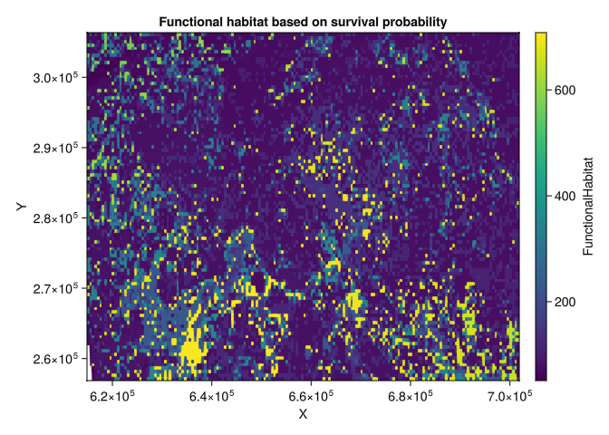

Amount of connected habitat based on survival connectivity.

## Summary

The ConScape library allows users to define the cost of movement between adjacent pixels both as a transformation from the likelihood of movement, but also from independent cost data. This application is very useful to model dispersal with mortality ((Fletcher Jr et al. 2019)), but could also be applied in combination with ‘energy landscapes’ discussed in: (Moorter et al. 2021).

Fletcher Jr, Robert J, Jorge A Sefair, Chao Wang, et al. 2019. “Towards a Unified Framework for Connectivity That Disentangles Movement and Mortality in Space and Time.” *Ecology Letters* 22 (10): 1680–89.

Marx, Andrew J, Chao Wang, Jorge A Sefair, Miguel A Acevedo, and Robert J Fletcher Jr. 2020. “Samc: An r Package for Connectivity Modeling with Spatial Absorbing Markov Chains.” *Ecography*.

Moorter, Bram van, Ilkka Kivimäki, Manuela Panzacchi, and Marco Saerens. 2021. “Defining and Quantifying Effective Connectivity of Landscapes for Species’ Movements.” *Ecography* 44 (6): 870–84.